# act_report

## Report: act_report

- Create a **250-word-minimum written report** called "act_report.pdf" or "act_report.html" that communicates the insights and displays the visualization(s) produced from your wrangled data. This is to be framed as an external document, like a blog post or magazine article, for example.

After data wrangling comes Analysis and Visualization to obtain insights from your data which can be used to communicate with relevant stakeholders

### Project Information

The dataset that we will be analyzing and visualizing is the tweet archive of Twitter user @dog_rates, also known as WeRateDogs. WeRateDogs is a Twitter account that rates people's dogs with a humorous comment about the dog.

## Analysis

There are several analysis that can be done on the WeRateDogs data, I have done 3 analysis and provide 3 insights.

First i defined the questions i wanted answers to from my dataset and they are

##### Questions

1. What are the top 5 most popular dog names?
2. What day of the week do people tweet mostly about dogs?
3. What are the top 5 dog breeds in the p1 column?

## Insights

1. The dataset has various names that were given to the dogs that were tweeted. Names are important because they give a personal conenction especially to dogs.

   Ignoring the None labels, **the top 5 most popular dog names are**

   ```
    1. Charlie
    2. Oliver
    3. Lucy
    4. Cooper
    5. Penny
   ```

1. Timestamps are important in data and markerting to determine the days most people are on social media which could be used to target ads. **The timestamps for the WeRateDogs data tells us that Mondays has the highest tweets.**
1. Dog Breed popularity: The most popular dogs breeds are:

   ```
    1. Golden Retriever
    2. Labrador Retriever
    3. Pembroke
    4. Chihuahua
    5. pug
   ```

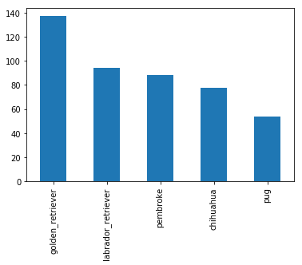

## Visualizations

There is a positive correlation between the retweet counts (how much a post was retweeted) and favourite ("likes") counts. The correlation is important to understand when determining methods to incread users traffic.

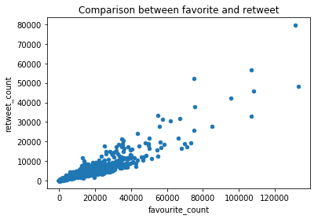